# Análisis Espacial de la Deserción Escolar en Colombia, 2023

Santiago Vera - Ricardo Salazar - Daniel Puentes

2025-07-03

# Contextualizacion base de datos

La deserción escolar es uno de los desafíos más significativos para el desarrollo social y económico de Colombia. No solo limita las oportunidades futuras de los individuos, sino que también perpetúa ciclos de pobreza y desigualdad a nivel regional. Entender cómo se distribuye este fenómeno en el territorio es fundamental para diseñar políticas públicas más efectivas y focalizadas.

Este estudio se enfoca en analizar si las tasas de deserción escolar departamentales para el año 2023 presentan patrones de concentración geográfica, es decir, si existen “focos calientes” de alta deserción o “focos fríos” de baja deserción en el país.

Para llevar a cabo este análisis, se utilizó un conjunto de datos del **Ministerio de Educación Nacional de Colombia** correspondiente al año 2023. La base de datos consolida los siguientes indicadores a nivel departamental:

- **Tasa de deserción escolar (%):** La variable principal de nuestro estudio.
- **Tasa de aprobación y reprobación (%):** Indicadores clave del desempeño académico.
- **Presupuesto educativo ajustado:** Variable económica que puede influir en la calidad y retención escolar.
- **Población entre 5 y 16 años:** Variable demográfica para contextualizar la población objetivo.

# Pregunta de Investigacion

¿Existe autocorrelación espacial en las tasas de deserción escolar departamentales en Colombia para el año 2023? En caso afirmativo, ¿qué variables educacionales (como aprobación o reprobación) y socioeconómicas (como presupuesto educativo o población) explican mejor dicha distribución espacial?

```r
library(stringi)
library(ggplot2)
library(leaflet)
library(sf)
library(sp)
library(tidyverse)
library(spdep)
library(spatialreg)
library(gridExtra)
library(patchwork)
library(lmtest)
library(car)
library(tmap)
```

```r
datos_ajustados <- read.csv("datos_ajustados.csv")%>%
  mutate(DEPARTAMENTO = DEPARTAMENTO %>%
           toupper() %>%
           stri_trans_general("Latin-ASCII")) %>%
  filter(AÑO == 2023)%>%
  filter(!row_number() %in% c(28))  # elimina filas 5, 10 y 25

Mapa <- st_read("colombia.geo.json") %>%
  mutate(NOMBRE_DPT = case_when(
    row_number() == 3  ~ "BOGOTA, D.C.",
    row_number() == 17  ~ "NARINO",
    TRUE ~ NOMBRE_DPT
  ))%>%
  filter(!row_number() %in% c(33))  # elimina filas 5, 10 y 25
datos <- datos_ajustados %>%
  left_join(
    Mapa %>%
      select(NOMBRE_DPT, geometry),  # Solo columnas deseadas
    by = c("DEPARTAMENTO" = "NOMBRE_DPT")
  )
```

```r
datos <- st_as_sf(datos)
datos <- st_make_valid(datos)
```

Se propone un mapa coroplético en el cual se ilustran los intervalos correspondientes a los cuantiles de la variable deserción a lo largo de todos los departamentos de Colombia. Los bins utilizados fueron: $(2.120, 3.478]$, $(3.478, 4.290]$, $(4.290, 5.062]$, $(5.062, 6.890]$, los cuales representan los valores de los cuantiles de dicha variable.

```r
# Definir los cortes manualmente
bins <- c(2.120, 3.478, 4.290   , 5.062   , 6.890 )

mypalette <- colorBin(
  palette = "YlOrRd",
  domain = datos$DESERCIÓN,
  bins = bins,
  na.color = "black"
)
```

```r
leaflet(data = datos) %>%
  addTiles() %>%
  addPolygons(
    fillColor = mypalette(datos$DESERCIÓN),
    fillOpacity = 0.9,
    color = "white",
    weight = 1,
    popup = paste0(
      "<strong>Barrio: </strong>", datos$DEPARTAMENTO,
      "<br><strong>Proporción: </strong>", round(datos$DESERCIÓN, 2), "%"
    ),
    highlight = highlightOptions(
      weight = 2,
      color = "lightgreen",
      bringToFront = TRUE
    )
  ) %>%
  addLegend(
    title = "Proporción (%)",
    pal = mypalette,
    values = datos$DESERCIÓN,
    opacity = 0.9
  ) %>%
  addProviderTiles(providers$Stadia.StamenToner)
```

[interactive chart not shown]

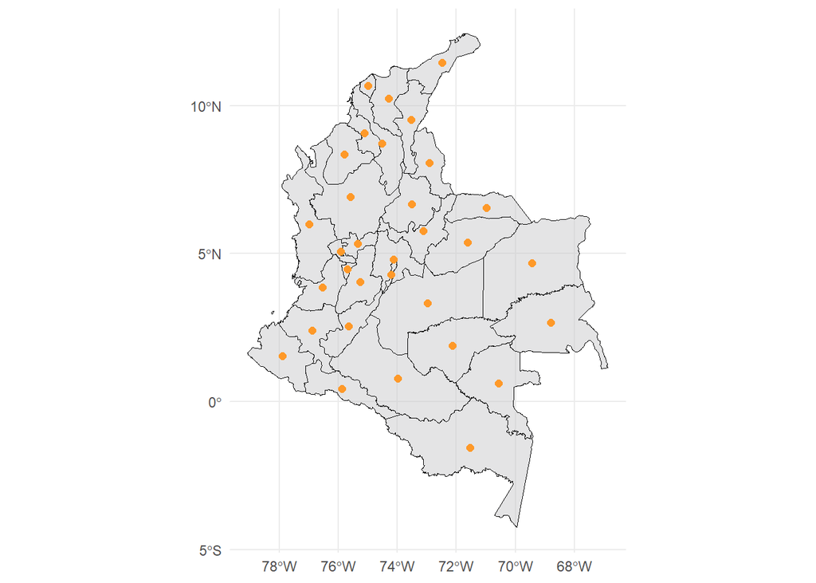

```r
geometria<-datos$geometry
centros <- st_centroid(geometria)

# Graficar el mapa con los polígonos y sus centroides
ggplot() +
  geom_sf(data = geometria, fill = "#CACACB", color = "black", alpha = 0.5) +
  geom_sf(data = centros, color = "#fe9929", size = 2) +
  theme_minimal()
```

# Matriz de vecindades

Se seleccionó el criterio de contigüidad de Reina (Queen) porque es más inclusivo que el de Torre (Rook), considerando como vecinos a los departamentos que comparten al menos un punto en sus fronteras. Esto es adecuado para geografías con polígonos irregulares como las de Colombia.

```r
matriz<-poly2nb(geometria,queen = T)
```

```r
library(knitr)

tabla_vecindad <- data.frame(
  Descripción = c("Número de regiones",
                  "Número de enlaces no nulos",
                  "Porcentaje de pesos no nulos",
                  "Promedio de enlaces por región"),
  Valor = c("32", "146", "14.26%", "4.5625")
)

kable(tabla_vecindad, caption = "Resumen del objeto de vecindad espacial (lista de vecinos)")
```

Resumen del objeto de vecindad espacial (lista de vecinos)

| Descripción | Valor |
| --- | --- |
| Número de regiones | 32 |
| Número de enlaces no nulos | 146 |
| Porcentaje de pesos no nulos | 14.26% |
| Promedio de enlaces por región | 4.5625 |

Número de regiones: son las unidades espaciales (en este caso, 32 departamentos de Colombia).

Número de enlaces no nulos: indica cuántas relaciones de vecindad se definieron (146 pares de vecinos).

Porcentaje de pesos no nulos: corresponde a la proporción de celdas no nulas en la matriz de pesos espaciales W, aquí 14.26%. Esto indica que la matriz es bastante dispersa.

Promedio de enlaces por región: cada departamento, en promedio, tiene aproximadamente 4.56 vecinos, lo cual es razonable dada la geografía de Colombia.

```r
# Coordenadas de los centroides (ya calculados con st_centroid)
coords <- sf::st_coordinates(centros)

# Crear líneas de vecindad como objeto sf
grafo_vecindad <- spdep::nb2lines(
  matriz,
  coords = coords,
  proj4string = "WGS84",
  as_sf = TRUE
)
```

```r
pesos <- nb2listw(matriz,style = "C")
```

|  | Valor |
| --- | --- |
| Estilo | C |
| $n$ | 32 |
| $n^2$ | 1024 |
| $W_0$ | 32 |
| $W_1$ | 14.0274 |
| $W_2$ | 147.9602 |

$$\text{Var}(I) = \frac{n^2 (n - 1) W_1 - n(n - 1) W_2 - 2 W_0^2}{(n +
1)(n - 1)^2 W_0^2}$$

Se aplica un style=“C” (global standardization), donde los pesos se estandarizan de tal forma que la suma de todos los enlaces de la matriz es igual al número de regiones (n=32).

La elección de este estilo, en lugar del más común style=“W” (que promedia la influencia de los vecinos), es una decisión teórica basada en la geografía y la estructura socioeconómica de Colombia. Se justifica al considerar que los departamentos con más conexiones y mayor centralidad (como los de la región Andina) pueden ejercer una influencia sistémica mayor en la dinámica educativa nacional.

# Grafo de adyacencia

Para definir de forma correcta quien es vecino de quien, se debe tener en cuenta que los departamentos que comparten frontera son vecinos, y por lo tanto deben estar conectados en el grafo. En este caso, se utiliza la función poly2nb para crear una matriz de adyacencia basada en la geometría de los departamentos.

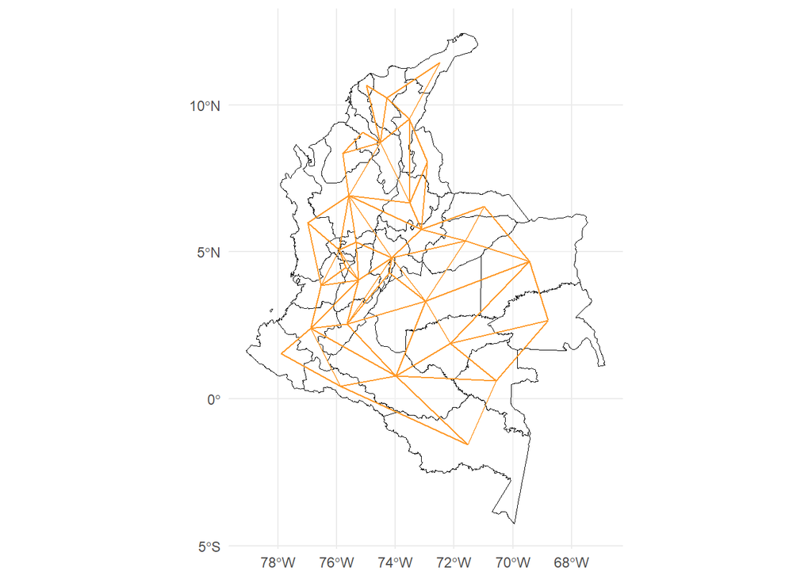

```r
# Coordenadas de los centroides (ya calculados con st_centroid)
coords <- sf::st_coordinates(centros)

# Crear líneas de vecindad como objeto sf
grafo_vecindad <- spdep::nb2lines(
  matriz,
  coords = coords,
  proj4string = "WGS84",
  as_sf = TRUE
)

# Visualizar el grafo sobre los polígonos
ggplot() +
  geom_sf(data = geometria, fill = "white", color = "black", alpha = 0.3) +
  geom_sf(data = grafo_vecindad, color = "#fe9929") +  # líneas del grafo en verde oscuro
  theme_minimal()
```

# Test de Moran

Para evaluar la autocorrelación espacial de la variable de interés, se utiliza el test de Moran. Este test permite determinar si existe una correlación espacial significativa entre los valores de la variable en diferentes regiones. Su hipótesis es:

$H_0$: No hay autocorrelación espacial en los valores de la variable de interés.

$H_1$: Existe autocorrelación espacial en los valores de la variable de interés.

```r
moran.test(datos$DESERCIÓN, pesos)
```

```
##
##  Moran I test under randomisation
##
## data:  datos$DESERCIÓN
## weights: pesos
##
## Moran I statistic standard deviate = 1.8481, p-value = 0.0323
## alternative hypothesis: greater
## sample estimates:
## Moran I statistic       Expectation          Variance
##        0.16373509       -0.03225806        0.01124737
```

El estadístico I de Moran de 0.1637 indica una autocorrelación espacial positiva. Esto significa que, en general, los departamentos con valores similares de deserción tienden a estar juntos, formando clústeres.

Dado que el valor p es 0.0323, que es menor que el nivel de significancia de 0.05, se rechaza la hipótesis nula. Esto confirma que el agrupamiento observado es estadísticamente significativo y no es producto del azar.

## Diagrama de Moran

Para representar el Test de Moran de forma visual, se utiliza un diagrama de Moran. Este diagrama muestra la relación entre los valores de la variable de interés y su promedio espacial (lag). Los puntos en el diagrama representan cada departamento, y su posición indica si tienen una alta o baja deserción en relación con sus vecinos.

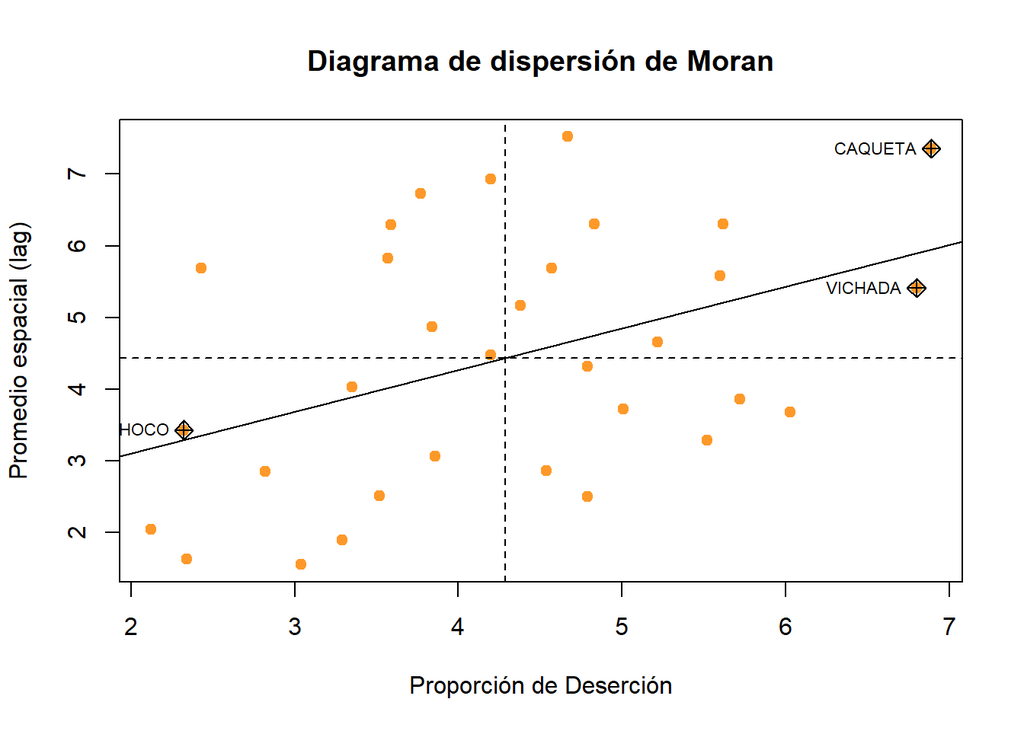

```r
mp <- moran.plot(
  datos$DESERCIÓN,
  listw = pesos,
  labels = as.character(datos$DEPARTAMENTO),
  pch = 19,
  col = "#fe9929",
  xlab = "Proporción de Deserción",
  ylab = "Promedio espacial (lag)",
  main = "Diagrama de dispersión de Moran"
)
```

La mayoría de los puntos (departamentos) se ubican en los cuadrantes inferior-izquierdo (Bajo-Bajo) y superior-derecho (Alto-Alto). Esta distribución confirma la tendencia positiva que encontró el Test de Moran.

- Los departamentos en el cuadrante Alto-Alto tienen alta deserción y están rodeados de vecinos con alta deserción (potenciales puntos calientes).
- Los departamentos en el cuadrante Bajo-Bajo tienen baja deserción y están rodeados de vecinos con baja deserción (potenciales puntos fríos).

# Analisis LISA

Por ultimo, se realiza un análisis LISA (Local Indicators of Spatial Association) para identificar clusters espaciales de alta y baja deserción escolar. Este análisis permite detectar patrones locales de autocorrelación espacial que no son evidentes en el análisis global.

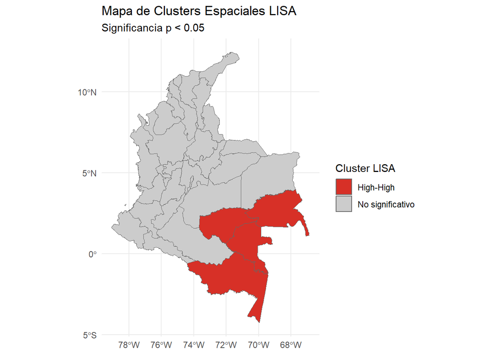

```r
lisa <- localmoran(datos$DESERCIÓN, pesos)

# Clasifica en cuadrantes
mean_var <- mean(datos$DESERCIÓN, na.rm = TRUE)
quad_sig <- rep(NA, nrow(lisa))

quad_sig[datos$DESERCIÓN > mean_var & lisa[,1] > 0 & lisa[,5] < 0.05] <- "High-High"
quad_sig[datos$DESERCIÓN < mean_var & lisa[,1] > 0 & lisa[,5] < 0.05] <- "Low-Low"
quad_sig[datos$DESERCIÓN > mean_var & lisa[,1] < 0 & lisa[,5] < 0.05] <- "High-Low"
quad_sig[datos$DESERCIÓN < mean_var & lisa[,1] < 0 & lisa[,5] < 0.05] <- "Low-High"
quad_sig[is.na(quad_sig)] <- "No significativo"

datos$cluster <- factor(quad_sig, levels = c("High-High", "Low-Low", "High-Low", "Low-High", "No significativo"))

colores <- c(
  "High-High" = "#d73027",
  "Low-Low" = "#4575b4",
  "High-Low" = "#fdae61",
  "Low-High" = "#abd9e9",
  "No significativo" = "grey80"
)

ggplot(datos) +
  geom_sf(aes(fill = cluster), color = "gray40", size = 0.1) +
  scale_fill_manual(values = colores, na.value = "white") +
  theme_minimal() +
  labs(
    fill = "Cluster LISA",
    title = "Mapa de Clusters Espaciales LISA",
    subtitle = "Significancia p < 0.05"
  )
```

```r
# Crear el vector IPM
IPM <- c(9.5, 12.0, 3.6, 18.4, 9.9, 7.4, 17.2, 15.8, 17.7, 21.4,
         7.6, 37.4, 11.9, 42.6, 21.4, 12.9, 16.6, 20.5, 7.5, 11.8,
         9.8, 23.1, 12.9, 7.2, 22.8, 15.0, 13.2, 25.4, 52.1,
         30.6, 55.7, 65.4)

# Añadir la columna IPM al data frame datos
datos$IPM <- IPM
```

## Covariables

### IPM

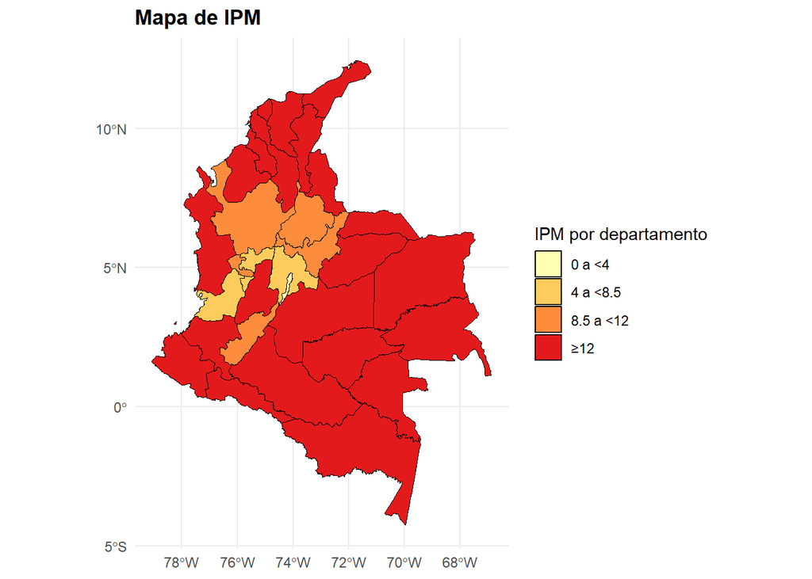

```r
# Definir los intervalos personalizados (cortes)
datos$clase_IPM <- cut(
  datos$IPM,
  breaks = c(0, 4, 8.5, 12, Inf),
  include.lowest = TRUE,
  right = FALSE,
  labels = c("0 a <4", "4 a <8.5", "8.5 a <12", "≥12")
)

# Crear el mapa estático
ggplot(data = datos) +
  geom_sf(aes(fill = clase_IPM), color = "black", size = 0.2) +
  scale_fill_brewer(
    palette = "YlOrRd",
    name = "IPM por departamento"
  ) +
  labs(title = "Mapa de IPM") +
  theme_minimal() +
  theme(
    legend.position = "right",
    plot.title = element_text(size = 13, face = "bold")
  )
```

El mapa muestra una marcada diferencia en el Índice de Pobreza Multidimensional (IPM) entre los departamentos de Colombia. Los departamentos de la región Andina presentan los niveles mas bajos de IPM, mientras que los del suroriente, como Guaviare y Vaupés, tienen los niveles más altos. Esto sugiere que la pobreza multidimensional es un factor crítico que podría influir en la deserción escolar.

### Aprobación

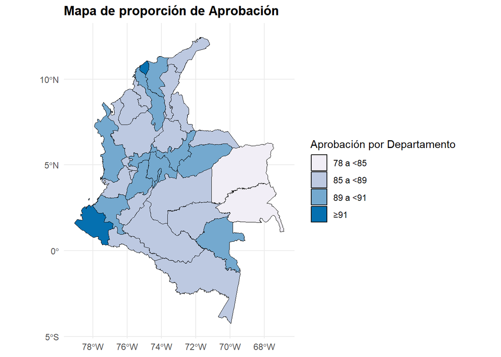

```r
# Definir los intervalos personalizados (cortes)
datos$clase_AP <- cut(
  datos$APROBACIÓN,
  breaks = c(78, 85, 89, 91, Inf),
  include.lowest = TRUE,
  right = FALSE,
  labels = c("78 a <85", "85 a <89", "89 a <91", "≥91")
)

# Crear el mapa estático
ggplot(data = datos) +
  geom_sf(aes(fill = clase_AP), color = "black", size = 0.2) +
  scale_fill_brewer(
    palette = "PuBu", # Paleta Amarillo-Verde
    name = "Aprobación por Departamento"
  ) +
  labs(title = "Mapa de proporción de Aprobación") +
  theme_minimal() +
  theme(
    legend.position = "right",
    plot.title = element_text(size = 13, face = "bold")
  )
```

Las tasas de aprobación mas altas se concentran en las regiones Pacifica y Andina (especialmente Nariño). Mientras que los niveles mas bajos se concentran en la región de la Orinoquia.

### Presupuesto

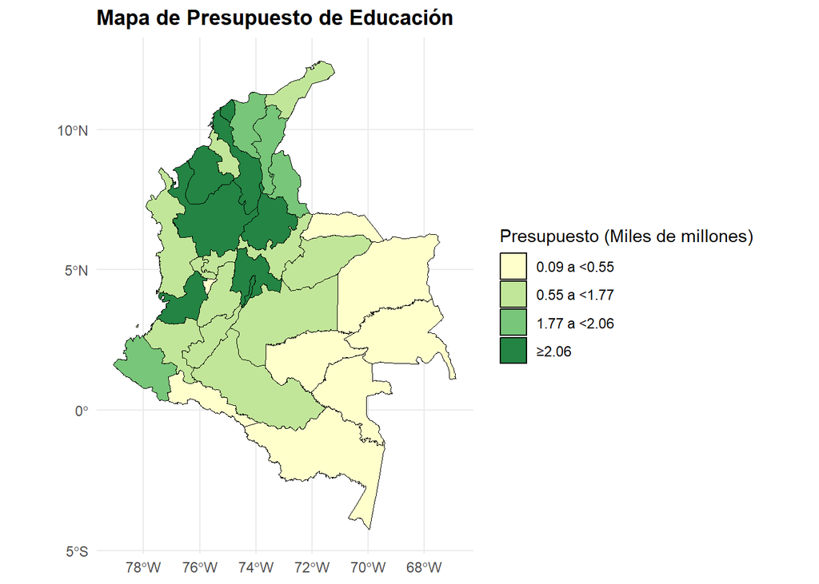

```r
# Definir los intervalos personalizados (cortes)
datos$clase_PE <- cut(
  datos$Presupuesto.educacion,
  breaks = c(0.09, 0.55, 1.77, 2.06, Inf),
  include.lowest = TRUE,
  right = FALSE,
  labels = c("0.09 a <0.55", "0.55 a <1.77", "1.77 a <2.06", "≥2.06")
)

# Crear el mapa estático
ggplot(data = datos) +
  geom_sf(aes(fill = clase_PE), color = "black", size = 0.2) +
  scale_fill_brewer(
    palette = "YlGn", # Paleta Amarillo-Verde
    name = "Presupuesto (Miles de millones)"
  ) +
  labs(title = "Mapa de Presupuesto de Educación ") +
  theme_minimal() +
  theme(
    legend.position = "right",
    plot.title = element_text(size = 13, face = "bold")
  )
```

La inversión en educación esta fuertemente concentrada en la región Andina (donde estan los departamentos mas poblados como Antioquia y Bogotá) y en menor medida en la región Caribe. En contraste, los departamentos del suroriente (región Amazonia y Orinoquia) reciben una inversión significativamente menor.

### Cobertura

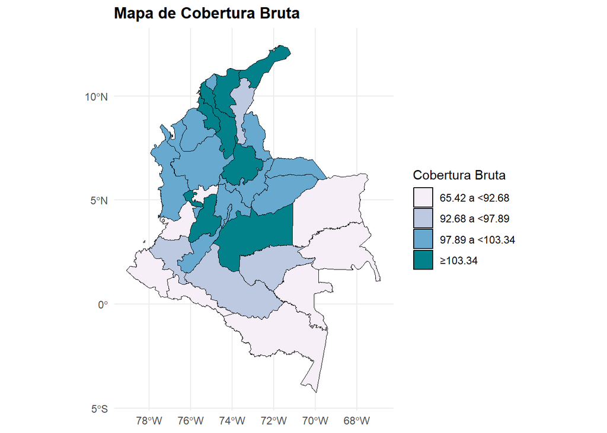

```r
# Definir los intervalos personalizados (cortes)
datos$clase_CB <- cut(
  datos$COBERTURA_BRUTA,
  breaks = c(65.42, 92.68, 97.89, 103.34, Inf),
  include.lowest = TRUE,
  right = FALSE,
  labels = c("65.42 a <92.68", "92.68 a <97.89", "97.89 a <103.34", "≥103.34")
)

# Crear el mapa estático
ggplot(data = datos) +
  geom_sf(aes(fill = clase_CB), color = "black", size = 0.2) +
  scale_fill_brewer(
    palette = "PuBuGn",
    name = "Cobertura Bruta"
  ) +
  labs(title = "Mapa de Cobertura Bruta") +
  theme_minimal() +
  theme(
    legend.position = "right",
    plot.title = element_text(size = 13, face = "bold")
  )
```

La Cobertura Bruta representa el porcentaje de estudiantes matriculados en un determinado nivel educativo respecto a la población oficial en edad teórica para cursar dicho nivel. Es decir, nos permite estimar qué tanto del grupo poblacional que debería estar escolarizado efectivamente lo está.

Sin embargo, este indicador puede superar el 100%, y esto no necesariamente implica una mejora en el acceso a la educación. Este fenómeno puede explicarse por varias razones:

Movilidad Estudiantil: Durante el año, estudiantes pueden trasladarse de un departamento a otro, generando duplicidades temporales o concentraciones de matrícula en ciertos territorios.

Migración Internacional: En los últimos años, la migración, especialmente desde Venezuela, ha presionado el sistema educativo en varios departamentos, llevando a un aumento en la matrícula que no necesariamente corresponde con la planificación local, generando en algunos casos sobrecobertura.

No refleja calidad ni permanencia: Una cobertura alta no garantiza permanencia, calidad del servicio educativo ni éxito académico. Es posible tener altas tasas de cobertura y, al mismo tiempo, altos niveles de deserción o bajo rendimiento.

Por tanto, aunque la cobertura bruta es un indicador útil para monitorear el acceso general al sistema educativo, no debe interpretarse de forma aislada. Su análisis debe complementarse con otros indicadores como las covariables explicadas anteriormente.

## Modelo empleado

Tras confirmar en el Test de Moran la presencia de autocorrelación espacial en la variable de deserción escolar, se procede a ajustar un modelo SAR (Spatial Autoregressive Model) para capturar esta dependencia espacial. Este modelo es apropiado porque se asume que la tasa de deserción de un departamento está directamente influenciada por las tasas de sus vecinos.

### Ecuacion Modelo SAR

$$Y=\rho WY + X \beta + \epsilon$$

Donde $\rho$ es el parametro de autocorrelacion espacial, $W$ es la matriz de pesos recordemos que se utilizo el estilo tipo “C”, $X$ es la matriz de covariables, $\beta$ es el vector de coeficientes de las covariables y $\epsilon$ es el termino de error aleatorio.

Este modelo incluye las covariables seleccionadas: tasa de aprobación, índice de pobreza multidimensional (IPM), presupuesto educativo y cobertura bruta.

```r
modelo_sar <- lagsarlm(DESERCIÓN ~ APROBACIÓN + IPM + Presupuesto.educacion + COBERTURA_BRUTA, data = datos, listw = pesos)
summary(modelo_sar)
```

```
##
## Call:
## lagsarlm(formula = DESERCIÓN ~ APROBACIÓN + IPM + Presupuesto.educacion +
##     COBERTURA_BRUTA, data = datos, listw = pesos)
##
## Residuals:
##       Min        1Q    Median        3Q       Max
## -1.345722 -0.394828 -0.055083  0.466034  1.301841
##
## Type: lag
## Coefficients: (asymptotic standard errors)
##                        Estimate Std. Error z value  Pr(>|z|)
## (Intercept)           38.245543   4.649343  8.2260 2.220e-16
## APROBACIÓN            -0.359125   0.049438 -7.2642 3.753e-13
## IPM                   -0.026690   0.010896 -2.4495   0.01430
## Presupuesto.educacion -0.170668   0.073319 -2.3277   0.01993
## COBERTURA_BRUTA       -0.022820   0.012696 -1.7975   0.07226
##
## Rho: 0.16009, LR test value: 5.3477, p-value: 0.02075
## Asymptotic standard error: 0.061957
##     z-value: 2.5838, p-value: 0.0097711
## Wald statistic: 6.6762, p-value: 0.0097711
##
## Log likelihood: -30.05315 for lag model
## ML residual variance (sigma squared): 0.38081, (sigma: 0.6171)
## Number of observations: 32
## Number of parameters estimated: 7
## AIC: 74.106, (AIC for lm: 77.454)
## LM test for residual autocorrelation
## test value: 0.13459, p-value: 0.71372
```

Del modelo se tiene la siguiente información:

- **Parámetro Espacial** ${\rho}$: El coeficiente Rho es 0.16 y es altamente significativo (p = 0.009). Esto confirma la presencia de un efecto de desbordamiento espacial. Un aumento en la tasa de deserción promedio de los vecinos se asocia con un aumento en la tasa de deserción del departamento en cuestión.
- **Coeficientes**:
  - **APROBACIÓN y Presupuesto.educacion**: tienen coeficientes negativos y significativos. Esto indica que un aumento en la tasa de aprobación y en el presupuesto educativo se asocia con una disminución en la deserción escolar, lo cual es teóricamente coherente.
  - **IPM**: también es significativo, pero su coeficiente negativo es contraintuitivo. Sugiere que, controlando por los otros factores, un mayor IPM se asocia a una menor deserción. Esto puede indicar interacciones complejas no modeladas o que las ayudas estatales se focalizan en zonas de alto IPM.
  - **COBERTURA_BRUTA**: no es estadísticamente significativa (p = 0.072), por lo que no se puede concluir que tenga un efecto real en este modelo.
- **Ajuste del Modelo (AIC)**: El AIC del modelo espacial (74.106) es menor que el de un modelo lineal equivalente (77.454), lo que justifica el uso del enfoque espacial.

**Nota**= Aunque la variable COBERTURA_BRUTA no es significativa al 5% (p ≈ 0.072), su inclusión en el modelo es valiosa desde el punto de vista explicativo y práctico, por las siguientes razones:

Al incluir COBERTURA_BRUTA, las variables IPM y Presupuesto en educación resultan estadísticamente significativas, lo que sugiere que esta variable ayuda a controlar una dimensión clave del fenómeno educativo.

Su presencia reduce el sesgo de omisión de variables relevantes. En otras palabras, aunque su coeficiente no es altamente significativo por sí mismo, mejora la interpretación y estimación de las otras variables.

COBERTURA_BRUTA refleja el grado de uso del sistema educativo en un año dado, es decir, qué proporción de la población objetivo está efectivamente matriculada.

Por eso, es un indicador indirecto de acceso real, presión sobre la infraestructura educativa y nivel de participación, todos ellos factores que influyen en la tasa de deserción.

Una menor cobertura puede reflejar dificultades de acceso o retención, lo cual explica por qué su efecto, aunque débilmente significativo, sigue siendo negativo en relación con la deserción.

**Test de Autocorrelación Espacial de los Residuales**: El valor p obtenido en la prueba (0.71372) es considerablemente mayor al umbral de significancia habitual (0.05). Esto implica que no se rechaza la hipótesis nula, la cual plantea que no existe autocorrelación espacial en los residuos del modelo. En otras palabras, los residuos muestran un comportamiento similar al ruido blanco, lo cual es un resultado deseable, ya que sugiere que el modelo SAR captura adecuadamente la estructura espacial presente en los datos. No quedan patrones espaciales sistemáticos sin modelar.

### Verificación de supuestos

Para asegurar la validez del modelo, se verifican los supuestos sobre los residuos:

#### Normalidad de los residuos

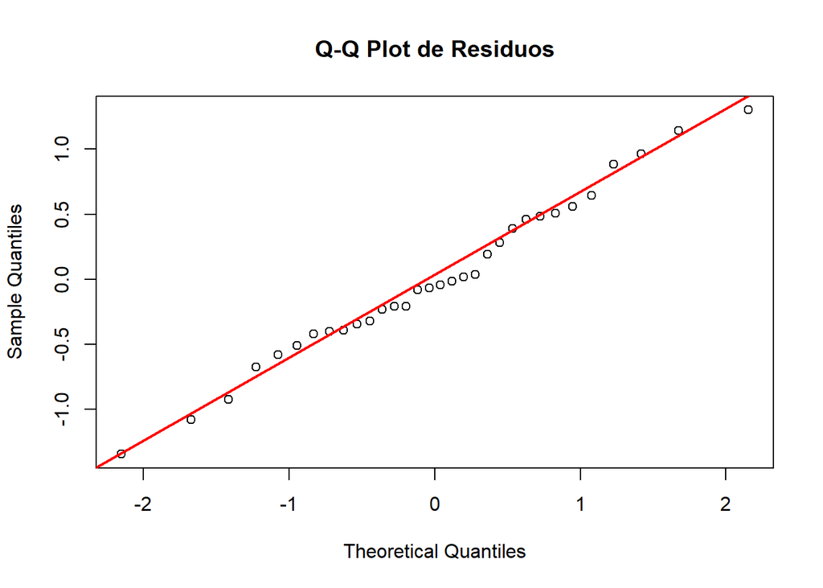

```r
residuos_modelo <- residuals(modelo_sar)

qqnorm(residuos_modelo, main = "Q-Q Plot de Residuos")
qqline(residuos_modelo, col = "red", lwd = 2)
```

```r
shapiro.test(residuos_modelo)
```

```
##
##  Shapiro-Wilk normality test
##
## data:  residuos_modelo
## W = 0.98687, p-value = 0.9568
```

El Q-Q plot muestra que los residuos se ajustan muy bien a una distribución normal. El test de Shapiro-Wilk confirma que no se rechaza la hipótesis nula de normalidad (p = 0.95), lo que sugiere que los residuos son aproximadamente normales.

#### Homocedasticidad y autocorrelación espacial

Se verifica que la varianza de los residuos sea constante y no dependa de los valores ajustados.

```r
ajustados_modelo <- fitted(modelo_sar)
```

```
## This method assumes the response is known - see manual page
```

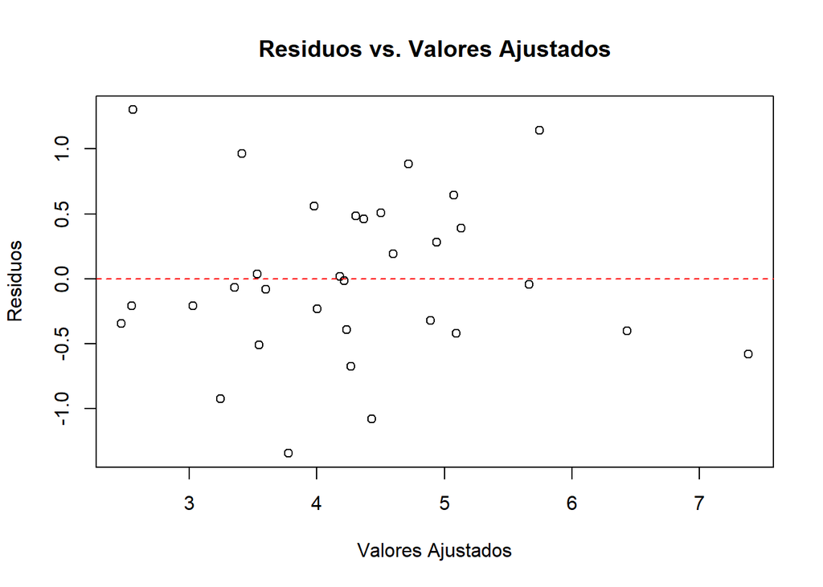

```r
plot(ajustados_modelo, residuos_modelo,
     main = "Residuos vs. Valores Ajustados",
     xlab = "Valores Ajustados",
     ylab = "Residuos")
abline(h = 0, col = "red", lty = 2)
```

```r
bptest(residuos_modelo ~ ajustados_modelo)
```

```
##
##  studentized Breusch-Pagan test
##
## data:  residuos_modelo ~ ajustados_modelo
## BP = 0.29627, df = 1, p-value = 0.5862
```

El gráfico de residuos muestra una dispersión aleatoria alrededor de cero, lo que sugiere homocedasticidad. El test de Breusch-Pagan indica que no hay evidencia de heterocedasticidad (p = 0.58), lo que respalda la validez del modelo.

#### Multicolinealidad

Se evalúa que las variables predictoras no estén fuertemente correlacionadas entre sí.

```r
modelo_lineal_vif <- lm(formula(modelo_sar), data = datos)

# Calcular el VIF
vif(modelo_lineal_vif)
```

```
##            APROBACIÓN                   IPM Presupuesto.educacion
##              1.358012              1.996145              1.314769
##       COBERTURA_BRUTA
##              1.435221
```

Los valores de VIF son todos menores a 5, lo que indica que no hay problemas significativos de multicolinealidad entre las variables predictoras. Esto sugiere que cada variable aporta información única al modelo.

## Visualización del Modelo SAR

Finalmente, se mapean los valores de deserción predichos por el modelo SAR. Este mapa no muestra la deserción real, sino la que el modelo estima a partir de las covariables y el efecto espacial. Es útil para visualizar la tendencia general que el modelo ha capturado y para identificar áreas donde el modelo sobreestima o subestima el fenómeno (es decir, donde los residuos son más grandes).

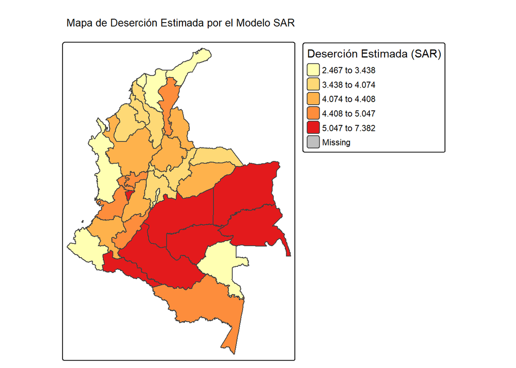

```r
datos$pred_car1 <- fitted(modelo_sar)

names(datos)[names(datos) == "pred_car1"] <- "Deserción Estimada (SAR)"

tmap_mode("plot")

tm_shape(datos) +
  tm_polygons(col = "Deserción Estimada (SAR)",
              style = "quantile",
              palette = c("#FFFFB2", "#FED976", "#FEB24C", "#FD8D3C", "#E31A1C")) +
  tm_layout(legend.outside = TRUE,
            main.title = "Mapa de Deserción Estimada por el Modelo SAR",
            main.title.size = 1.2)
```

Un hallazgo revelador de este mapa es el caso del departamento de Vaupés. Mientras que los análisis exploratorios (Moran y LISA) lo identificaron como un foco caliente de alta deserción (Alto-Alto), el modelo SAR le predice una de las tasas más bajas del país.

El modelo predice un valor bajo porque las variables predictoras de Vaupés (como su tasa de aprobación o presupuesto) se asemejan a las de departamentos que, en el resto del país, sí tienen baja deserción.

## Modelo Aprobación

Siguiendo las recomendaciones, se procede a ajustar un modelo más parsimonioso como contraste. El objetivo es evaluar si un modelo más simple, que incluye únicamente la variable más influyente y consistentemente significativa (APROBACIÓN), puede ofrecer una explicación robusta del fenómeno, aunque sea menos detallada.

### Construcción

```r
modelo_sar2 <- lagsarlm(DESERCIÓN ~ APROBACIÓN, data = datos, listw = pesos)
summary(modelo_sar2)
```

```
##
## Call:lagsarlm(formula = DESERCIÓN ~ APROBACIÓN, data = datos, listw = pesos)
##
## Residuals:
##      Min       1Q   Median       3Q      Max
## -1.32938 -0.44848 -0.14894  0.53678  1.46215
##
## Type: lag
## Coefficients: (asymptotic standard errors)
##              Estimate Std. Error z value  Pr(>|z|)
## (Intercept) 32.854052   4.185012  7.8504 4.219e-15
## APROBACIÓN  -0.335061   0.046891 -7.1455 8.966e-13
##
## Rho: 0.20297, LR test value: 7.0792, p-value: 0.0077983
## Asymptotic standard error: 0.068149
##     z-value: 2.9783, p-value: 0.0028988
## Wald statistic: 8.8701, p-value: 0.0028988
##
## Log likelihood: -34.23669 for lag model
## ML residual variance (sigma squared): 0.49276, (sigma: 0.70197)
## Number of observations: 32
## Number of parameters estimated: 4
## AIC: 76.473, (AIC for lm: 81.553)
## LM test for residual autocorrelation
## test value: 0.84086, p-value: 0.35915
```

La salida del modelo muestra que, incluso en este modelo simple, tanto el intercepto como el coeficiente de APROBACIÓN (-0.33) son altamente significativos. Crucialmente, el parámetro espacial Rho (0.20) sigue siendo positivo y estadísticamente significativo ($p \approx 0.003$), confirmando que la dependencia espacial es una característica intrínseca del fenómeno de la deserción.

### Supuestos

#### Normalidad de los residuos

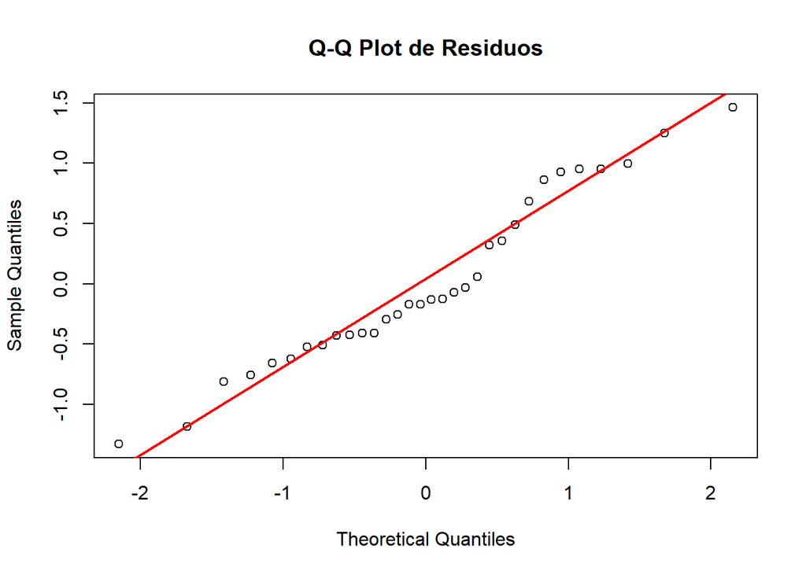

```r
residuos_modelo2 <- residuals(modelo_sar2)

qqnorm(residuos_modelo2, main = "Q-Q Plot de Residuos")
qqline(residuos_modelo2, col = "red", lwd = 2)
```

```r
shapiro.test(residuos_modelo2)
```

```
##
##  Shapiro-Wilk normality test
##
## data:  residuos_modelo2
## W = 0.9568, p-value = 0.2241
```

El Q-Q plot muestra que los residuos intentan ajustarse a una distribución normal, aunque con algunas desviaciones. El test de Shapiro-Wilk indica que no se rechaza la hipótesis nula de normalidad, lo que sugiere que los residuos son aproximadamente normales.

#### Homocedasticidad y autocorrelación espacial

```r
ajustados_modelo2 <- fitted(modelo_sar2)
```

```
## This method assumes the response is known - see manual page
```

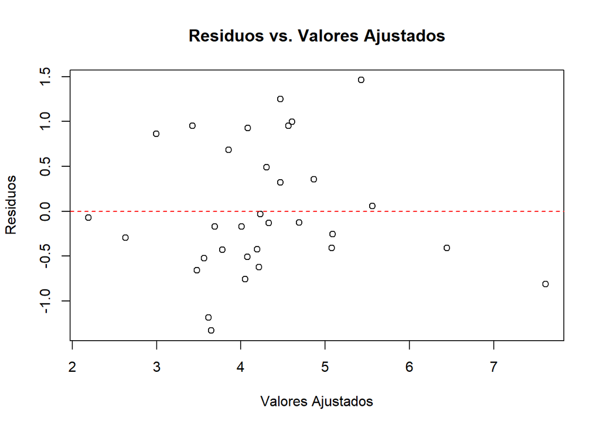

```r
plot(ajustados_modelo2, residuos_modelo2,
     main = "Residuos vs. Valores Ajustados",
     xlab = "Valores Ajustados",
     ylab = "Residuos")
abline(h = 0, col = "red", lty = 2)
```

```r
bptest(residuos_modelo ~ ajustados_modelo2)
```

```
##
##  studentized Breusch-Pagan test
##
## data:  residuos_modelo ~ ajustados_modelo2
## BP = 0.71398, df = 1, p-value = 0.3981
```

### Comparación de resultados

Ahora comparamos el modelo complejo (con 4 predictores) contra el modelo parsimonioso (con 1 predictor) para decidir cuál es más adecuado para responder la pregunta de investigación.

| **Métrica de Ajuste** | **Modelo Completo (4 Preds.)** | **Modelo Aprobación** | **Favorece a** |
| --- | --- | --- | --- |
| AIC | 74.106 | 76.473 | Modelo Completo |
| Log-Likelihood | -30.05 | -34.24 | Modelo Completo |
| Varianza Residual | 0.381 | 0.493 | Modelo Completo |

Las métricas de ajuste estadístico favorecen de manera clara al modelo más complejo.

- Tiene un AIC más bajo, lo que indica una menor pérdida de información.
- Su Log-Likelihood es mayor, señalando un mejor ajuste a los datos observados.
- La varianza residual es menor, lo que significa que el modelo complejo logra explicar una mayor proporción de la variabilidad de la deserción.

## Conclusiones

- El análisis confirma de manera estadísticamente significativa que la deserción escolar no se distribuye al azar, sino que presenta focos calientes de alta deserción, principalmente en la región suroriente del país. El modelo espacial SAR no solo valida esto, sino que demuestra un efecto de desbordamiento significativo, implicando que la deserción en un departamento está directamente influenciada por la de sus vecinos.
- La tasa de aprobación es el predictor más influyente y consistente en ambos modelos, lo que sugiere que mejorar la calidad educativa podría ser clave para reducir la deserción.
- Este análisis proporciona una herramienta valiosa para el diseño de políticas. Los esfuerzos no deben ser homogéneos, sino espacialmente focalizados en el clúster de alto riesgo identificado. Las intervenciones deberían priorizar estrategias para mejorar el desempeño académico y garantizar una inversión presupuestaria adecuada. Además, el modelo ayuda a identificar casos atípicos como Vaupés, señalando dónde se requieren análisis más profundos para entender las particularidades locales que impulsan la deserción.